# Ford GoBike Data Analysis and Visualization

## by Nada Ahmed

## Preliminary Wrangling

> The dataset includes information about individual rides made in a bike-sharing system covering the greater San Francisco Bay area in february 2019.

### What is the structure of your dataset?

> The dataset consists of 183412 rows and 16 features. There are 7 object type features (start_time,end_time,start_station_name,end_station_name,user_type,member_gender,bike_share_for_all_trip), and 9 numeric features(duration_sec,start_station_id,start_station_latitude,start_station_longitude,end_station_id,end_station_latitude,end_station_longitude,bike_id,member_birth_year).

### What features in the dataset do you think will help support your investigation into your feature(s) of interest?

> age, gender, duration (in minutes and seconds), user type, start station name, start time.

## Univariate Exploration

#### Average trip duration

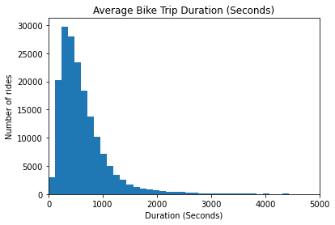

```python
bins = np.arange(0, bike_df_copy['duration_sec'].max() +1000 , 120)
plt.hist(data = bike_df_copy , x = 'duration_sec' , bins = bins)
plt.xlim(0,5000)
plt.title('Average Bike Trip Duration (Seconds)')
plt.xlabel('Duration (Seconds)');
plt.ylabel('Number of rides');
```

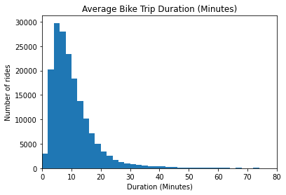

```python
bins = np.arange(0, bike_df_copy['duration_min'].max() +1 , 2)
plt.hist(data = bike_df_copy , x = 'duration_min' , bins = bins)
plt.xlim(0,80)
plt.title('Average Bike Trip Duration (Minutes)')
plt.xlabel('Duration (Minutes)');
plt.ylabel('Number of rides');
```

#### Age distribution

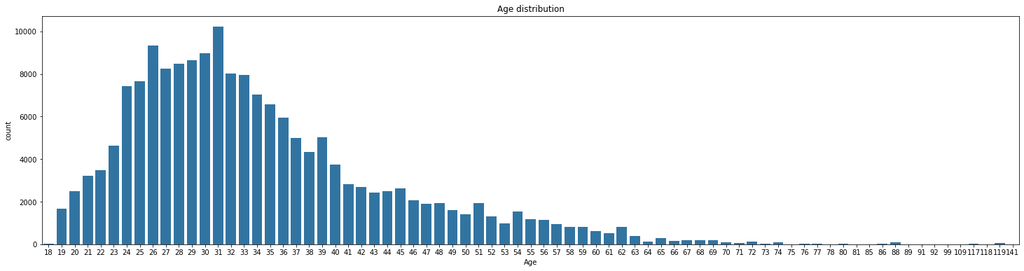

```python
plt.figure(figsize=(25,6))
sns.countplot(bike_df_copy['age'], color = sns.color_palette()[0]);
plt.xlabel('Age');
plt.title('Age distribution');
```

From this plot we can see that most users are between 20 to 40 years with the most common ages being 26 and 31.

#### Gender Counts Distribution

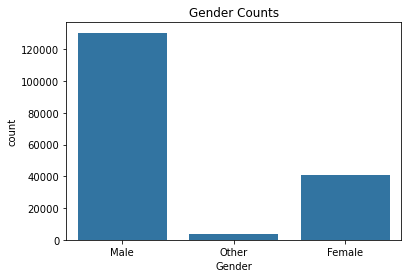

```python
sns.countplot(bike_df_copy['member_gender'], color = sns.color_palette()[0]);
plt.xlabel('Gender');
plt.title('Gender Counts');
```

From the above histogram we can observe that most of the riders are males.

#### User Types (Customer vs Subscriber)

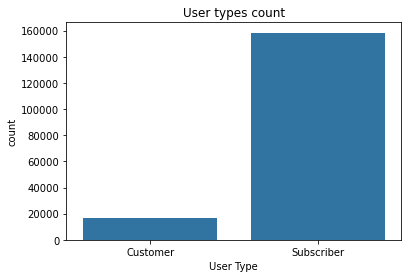

```python
sns.countplot(bike_df_copy['user_type'], color = sns.color_palette()[0]);
plt.xlabel('User Type');
plt.title('User types count');
```

From the above histogram we can observe that most of the users are Subscribers.

## Bivariate Exploration

#### Effect of age on trip duration

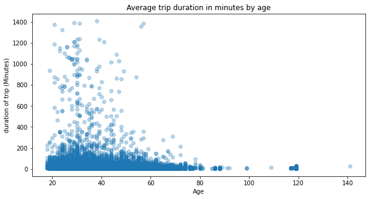

```python
plt.figure(figsize=(10,5))
plt.scatter((bike_df_copy['age']), bike_df_copy['duration_min'], alpha = 0.30 );
plt.xlabel('Age');
plt.ylabel('duration of trip (Minutes)');
plt.title('Average trip duration in minutes by age');
```

From plotting Age againist trip duration in minutes we can see that users between 20 and 40 years have the longest rides with the younger members having consistently more long trips.

#### Effect of gender on trip duration

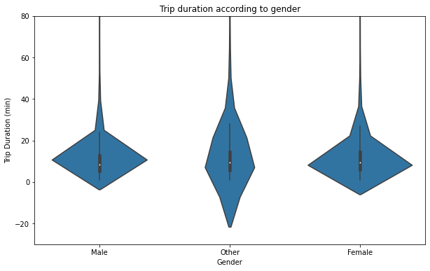

```python
plt.figure(figsize = [10, 6])
sns.violinplot(data=bike_df_copy, x='member_gender', y='duration_min', color=sns.color_palette()[0], innner=None)
plt.ylim([-30, 80]);
plt.xlabel('Gender');
plt.ylabel('Trip Duration (min)');
plt.title('Trip duration according to gender');
```

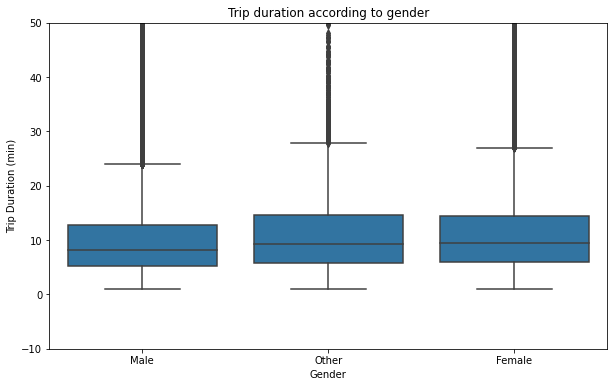

```python
plt.figure(figsize = [10, 6])
sns.boxplot(data = bike_df_copy, x = 'member_gender', y = 'duration_min', color = sns.color_palette()[0])
plt.ylim([-10, 50])
plt.xlabel('Gender')
plt.ylabel('Trip Duration (min)')
plt.title('Trip duration according to gender');
```

From the above plots we can observe an interesting fact. Although the number of male riders is more than that of females and others, females and others tend to have longer trip durations on average.

#### Effect of user type on trip duration

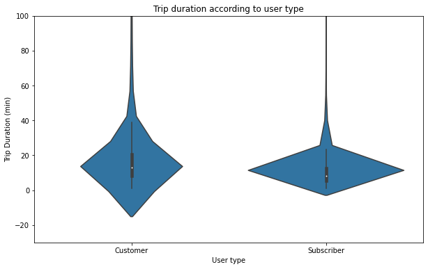

```python
plt.figure(figsize = [10, 6])
sns.violinplot(data=bike_df_copy, x='user_type', y='duration_min', color=sns.color_palette()[0], innner=None)
plt.ylim([-30, 100]);
plt.xlabel('User type')
plt.ylabel('Trip Duration (min)')
plt.title('Trip duration according to user type');
```

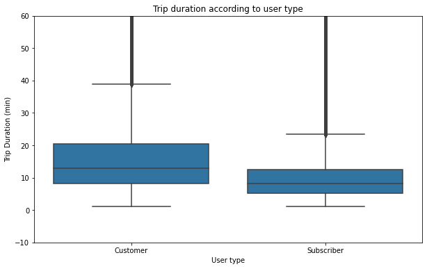

```python
plt.figure(figsize = [10, 6])
sns.boxplot(data = bike_df_copy, x = 'user_type', y = 'duration_min', color = sns.color_palette()[0])
plt.ylim([-10, 60])
plt.xlabel('User type')
plt.ylabel('Trip Duration (min)')
plt.title('Trip duration according to user type');
```

From the above plots we can observe that although the number of subscribers is much higher than that of customers, customers tend to have much longer trips than subscribers.